# Mendelian Randomization Tutorial: CRP, IL-6, and CHD

Tayyaba Alvi

# Introduction

This tutorial demonstrates how to perform a Mendelian Randomization (MR) analysis using multiple data sources. We explore the causal relationship between C-reactive protein (CRP) and coronary heart disease (CHD), followed by a deeper look at interleukin-6 (IL-6), a potential upstream regulator of CRP. The results highlight the contrast between observational and MR-based evidence and suggest that IL-6 signalling may play a more direct causal role in CHD risk.

# 1. Accessing GWAS Data from Different Sources

## 1.1 From Local VCF Files Using `gwasvcf_to_TwoSampleMR`

```r
vcf_crp <- VariantAnnotation::readVcf("data/ieugwas/CRP_ebi-a-GCST005067_sub.vcf.gz")
crp_exposure <- gwasvcf_to_TwoSampleMR(vcf_crp, "exposure")
crp_exposure <- crp_exposure %>% filter(pval.exposure < 5*10^-8)

vcf_chd <- VariantAnnotation::readVcf("data/ieugwas/CHD_ebi-a-GCST000998_sub.vcf.gz")
chd_outcome <- gwasvcf_to_TwoSampleMR(vcf_chd, "outcome")

harm_data <- harmonise_data(exposure_dat = crp_exposure, outcome_dat = chd_outcome)
```

```
## Harmonising EBI-a-GCST005067 (EjBsvU) and EBI-a-GCST000998 (q8fevf)
```

```
## Removing the following SNPs for being palindromic with intermediate allele frequencies:
## rs2257764
```

## 1.2 From MRBase API Using `MRInstruments`

```r
vignette("MRBase")
data(gwas_catalog)
exposure_gwas <- subset(gwas_catalog, grepl("GCST007615", STUDY.ACCESSION) &
                          Phenotype_simple == "C-reactive protein levels")
exposure_gwas <- exposure_gwas[exposure_gwas$pval < 5*10^-8, ]
exposure_data <- format_data(exposure_gwas)
head(exposure_data)
```

```
##           SNP chr.exposure gene.exposure effect_allele.exposure
## 1  rs10832027           11         ARNTL                      A
## 2 rs111269058            7         BCL7B                      T
## 3  rs11130206            3           BSN                      C
## 4 rs112635299           14      SERPINA1                      T
## 5  rs11265263            1           CRP                      A
## 6 rs116971887           16         SALL1                      T
##   other_allele.exposure beta.exposure se.exposure pval.exposure units.exposure
## 1                     G         0.023 0.004081633         3e-08  unit increase
## 2                     C        -0.054 0.006122449         3e-19  unit decrease
## 3                     G        -0.025 0.004081633         4e-10  unit decrease
## 4                     G        -0.107 0.016836735         2e-10  unit decrease
## 5                  <NA>        -0.273 0.007653061        1e-197  unit decrease
## 6                     G        -0.118 0.012244898         9e-25  unit decrease
##   eaf.exposure                                  exposure mr_keep.exposure
## 1         0.67 C-reactive protein levels (unit increase)             TRUE
## 2         0.12 C-reactive protein levels (unit decrease)             TRUE
## 3         0.60 C-reactive protein levels (unit decrease)             TRUE
## 4         0.02 C-reactive protein levels (unit decrease)             TRUE
## 5         0.07 C-reactive protein levels (unit decrease)            FALSE
## 6         0.05 C-reactive protein levels (unit decrease)             TRUE
##   pval_origin.exposure units.exposure_dat id.exposure
## 1             reported      unit increase      0KYo63
## 2             reported      unit decrease      au007o
## 3             reported      unit decrease      au007o
## 4             reported      unit decrease      au007o
## 5             reported      unit decrease      au007o
## 6             reported      unit decrease      au007o
```

```r
# Check available outcomes
#ao <- available_outcomes()
#head(ao)

# Extract CHD outcome data
#chd_outcome_api <- extract_outcome_data(
#  snps = exposure_data$SNP,
#  outcomes = 'ieu-a-7'
#)
```

## 1.3 From Local TSV Files Using `read_exposure_data`

```r
exposure <- read_exposure_data(
  filename = "data/gwas_catalogue/CRP-GCST005067_sub.tsv.gz",
  sep = "\t",
  snp_col = "variant_id",
  beta_col = "beta",
  se_col = "standard_error",
  effect_allele_col = "effect_allele",
  other_allele_col = "other_allele",
  eaf_col = "effect_allele_frequency",
  pval_col = "p_value"
)
```

```
## No phenotype name specified, defaulting to 'exposure'.
```

[output not shown]

[output cut: 248 more lines]

[output not shown]

```r
exposure$exposure <- "CRP"
exposure <- exposure %>% filter(pval.exposure < 5*10^-8)

outcome <- read_outcome_data(
  snps = exposure$SNP,
  filename = "data/gwas_catalogue/CHD_GCST000998.tsv.gz",
  sep = "\t",
  snp_col = "variant_id",
  beta_col = "beta",
  se_col = "standard_error",
  effect_allele_col = "effect_allele",
  other_allele_col = "other_allele",
  eaf_col = "effect_allele_frequency",
  pval_col = "p_value"
)
```

```
## No phenotype name specified, defaulting to 'outcome'.
```

```r
outcome$outcome <- "CHD"
```

# Overview

This part investigates the causal cascade from IL-6 signaling to coronary heart disease (CHD) through C-reactive protein (CRP), using Mendelian Randomization (MR). We’ll test whether genetic proxies for IL-6, IL6R, and CRP are causally associated with each other and with CHD.

**Summary of the cascade:**

1. **IL6R → CRP**: Evidence supports a strong causal effect, consistent with IL6R as an upstream driver of inflammation.
2. **CRP → CHD**: Evidence **does not** support a causal effect, suggesting CRP may be a **marker** rather than a driver of CHD.
3. **IL-6 → CHD**: Results suggest a potential causal role for IL-6 in CHD risk, but pleiotropy and heterogeneity must be considered.
4. **IL6R → CHD**: Provides a druggable link; may support IL6R-targeting interventions like tocilizumab.

# Harmonize and clump

```r
dat <- harmonise_data(exposure_dat = exposure, outcome_dat = outcome)
```

```
## Harmonising CRP (WraFh2) and CHD (bHVUvE)
```

```
## Removing the following SNPs for being palindromic with intermediate allele frequencies:
## rs1800947, rs1811472, rs2027471, rs2808624
```

```r
clump <- ld_clump(
  dplyr::tibble(rsid=dat$SNP, pval=dat$pval.exposure, id=dat$exposure),
  clump_kb = 1000,
  clump_r2 = 0.01,
  clump_p = 0.99,
  pop = "EUR",
  opengwas_jwt = get_opengwas_jwt(),
  bfile = NULL,
  plink_bin = NULL
)
```

```
## Please look at vignettes for options on running this locally if you need to run many instances of this command.
```

```
## Clumping CRP, 45 variants, using EUR population reference
```

```
## Removing 41 of 45 variants due to LD with other variants or absence from LD reference panel
```

```r
harm_clump <- merge(dat, clump, by.x = c("SNP", "pval.exposure", "exposure"), by.y = c("rsid", "pval", "id")) %>% unique()
```

# 1. MR Analysis of CRP on CHD

## Let’s test whether CRP levels have a causal effect on coronary heart disease.

```r
res <- mr(harm_clump, method_list = c("mr_egger_regression", "mr_ivw"))
```

```
## Analysing 'WraFh2' on 'bHVUvE'
```

```r
res
```

```
##   id.exposure id.outcome outcome exposure                    method nsnp
## 1      WraFh2     bHVUvE     CHD      CRP                  MR Egger    4
## 2      WraFh2     bHVUvE     CHD      CRP Inverse variance weighted    4
##            b        se      pval
## 1 -1.3137852 1.1708767 0.3784574
## 2 -0.0834739 0.1945596 0.6678939
```

```r
mr_heterogeneity(harm_clump)
```

```
##   id.exposure id.outcome outcome exposure                    method        Q
## 1      WraFh2     bHVUvE     CHD      CRP                  MR Egger 19.86567
## 2      WraFh2     bHVUvE     CHD      CRP Inverse variance weighted 31.13021
##   Q_df       Q_pval
## 1    2 4.855399e-05
## 2    3 7.980401e-07
```

```r
mr_pleiotropy_test(harm_clump)
```

```
##   id.exposure id.outcome outcome exposure egger_intercept        se      pval
## 1      WraFh2     bHVUvE     CHD      CRP       0.1664207 0.1562741 0.3984583
```

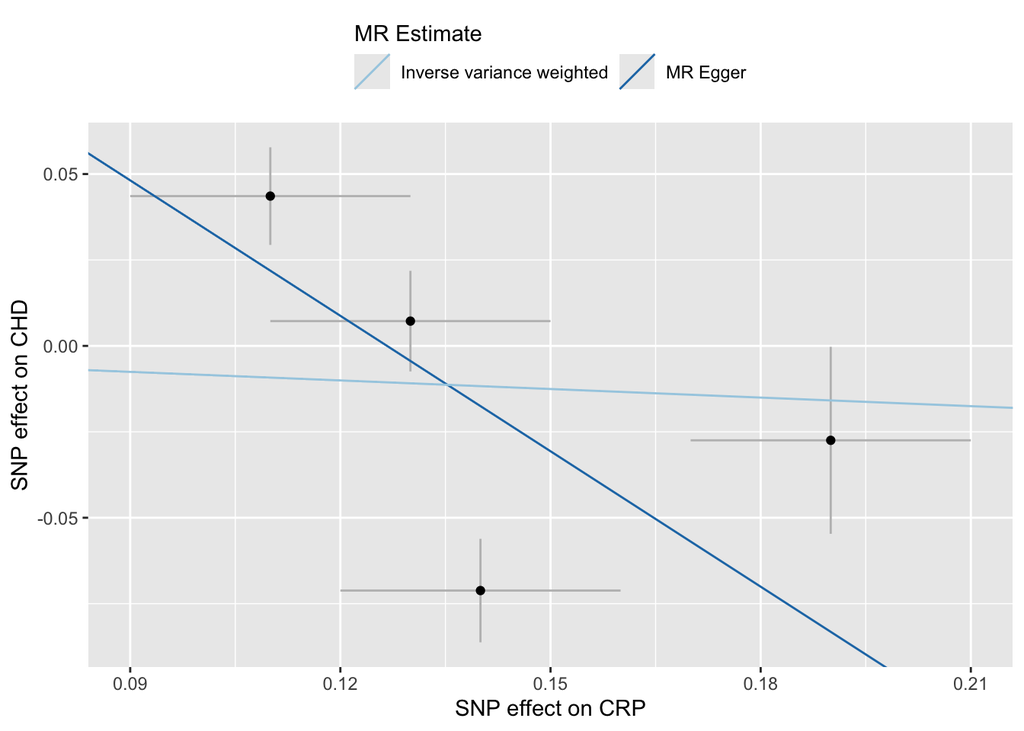

```
##
## attr(,"split_type")
## [1] "data.frame"
## attr(,"split_labels")
##   id.exposure id.outcome
## 1      WraFh2     bHVUvE
```

```r
# Plots
p1 <- mr_scatter_plot(res, harm_clump)
p1
```

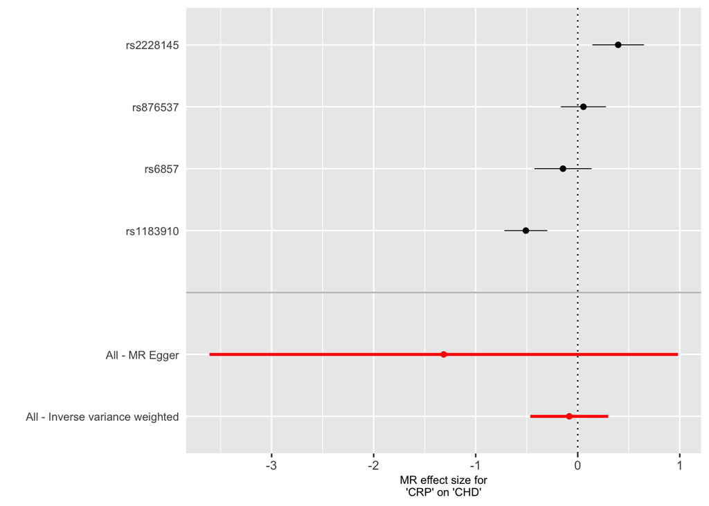

```
##
## attr(,"split_type")
## [1] "data.frame"
## attr(,"split_labels")
##   id.exposure id.outcome
## 1      WraFh2     bHVUvE
```

```r
res_single <- mr_singlesnp(harm_clump)
p2 <- mr_forest_plot(res_single)
p2
```

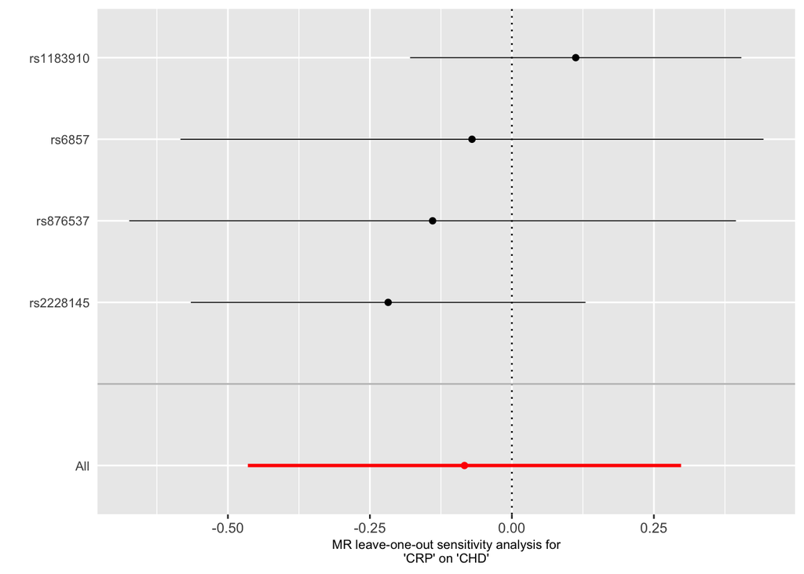

```
##
## attr(,"split_type")
## [1] "data.frame"
## attr(,"split_labels")
##   id.exposure id.outcome
## 1      WraFh2     bHVUvE
```

```r
res_loo <- mr_leaveoneout(harm_clump)
p3 <- mr_leaveoneout_plot(res_loo)
p3
```

```r
# Generate report
#mr_report(harm_clump, output_path = "figure/")
```

**Exercise:** - Do we observe a causal effect of CRP on CHD? - Are the MR assumptions violated based on pleiotropy and heterogeneity tests?

# 2. MR Analysis of IL-6 on CHD

Let’s test whether IL-6 levels are causally associated with CHD risk.

```r
exposure <- read_exposure_data(
  filename = "data/gwas_catalogue/IL6-GCST90012005_sub.tsv.gz",
  sep = "\t",
  snp_col = "variant_id",
  beta_col = "beta",
  se_col = "standard_error",
  effect_allele_col = "effect_allele",
  other_allele_col = "other_allele",
  eaf_col = "effect_allele_frequency",
  pval_col = "p_value"
)
```

```
## No phenotype name specified, defaulting to 'exposure'.
```

```r
exposure$exposure <- "IL-6"
exposure <- exposure %>% filter(pval.exposure < 5*10^-6)

outcome <- read_outcome_data(
  snps = exposure$SNP,
  filename = "data/gwas_catalogue/CHD_GCST000998.tsv.gz",
  sep = "\t",
  snp_col = "variant_id",
  beta_col = "beta",
  se_col = "standard_error",
  effect_allele_col = "effect_allele",
  other_allele_col = "other_allele",
  eaf_col = "effect_allele_frequency",
  pval_col = "p_value"
)
```

```
## No phenotype name specified, defaulting to 'outcome'.
```

```r
outcome$outcome <- "CHD"

il6_data <- harmonise_data(exposure_dat = exposure, outcome_dat = outcome)
```

```
## Harmonising IL-6 (dRBD6a) and CHD (IRg4hn)
```

```
## Removing the following SNPs for being palindromic with intermediate allele frequencies:
## rs9426831
```

```r
clump <- ld_clump(
  dplyr::tibble(rsid=il6_data$SNP, pval=il6_data$pval.exposure,exposure=il6_data$exposure),
  clump_kb = 1000,
  clump_r2 = 0.01,
  clump_p = 0.99,
  pop = "EUR",
  opengwas_jwt = get_opengwas_jwt(),
  bfile = NULL,
  plink_bin = NULL
)
```

```
## Please look at vignettes for options on running this locally if you need to run many instances of this command.
```

```
## Clumping BglZOp, 92 variants, using EUR population reference
```

```
## Removing 86 of 92 variants due to LD with other variants or absence from LD reference panel
```

```r
harm_clump_il6 <- merge(il6_data, clump, by.x = c("SNP", "pval.exposure", "exposure"), by.y = c("rsid", "pval", "exposure")) %>% unique()

res_il6 <- mr(harm_clump_il6, method_list = c("mr_egger_regression", "mr_ivw"))
```

```
## Analysing 'dRBD6a' on 'IRg4hn'
```

```r
res_il6
```

```
##   id.exposure id.outcome outcome exposure                    method nsnp
## 1      dRBD6a     IRg4hn     CHD     IL-6                  MR Egger    6
## 2      dRBD6a     IRg4hn     CHD     IL-6 Inverse variance weighted    6
##            b         se       pval
## 1 -0.4234409 0.14783102 0.04572799
## 2 -0.1333127 0.08409156 0.11289174
```

```r
mr_heterogeneity(harm_clump_il6)
```

```
##   id.exposure id.outcome outcome exposure                    method        Q
## 1      dRBD6a     IRg4hn     CHD     IL-6                  MR Egger 3.641813
## 2      dRBD6a     IRg4hn     CHD     IL-6 Inverse variance weighted 8.410826
##   Q_df    Q_pval
## 1    4 0.4566453
## 2    5 0.1350005
```

```r
mr_pleiotropy_test(harm_clump_il6)
```

```
##   id.exposure id.outcome outcome exposure egger_intercept         se      pval
## 1      dRBD6a     IRg4hn     CHD     IL-6      0.03222427 0.01475601 0.0943423
```

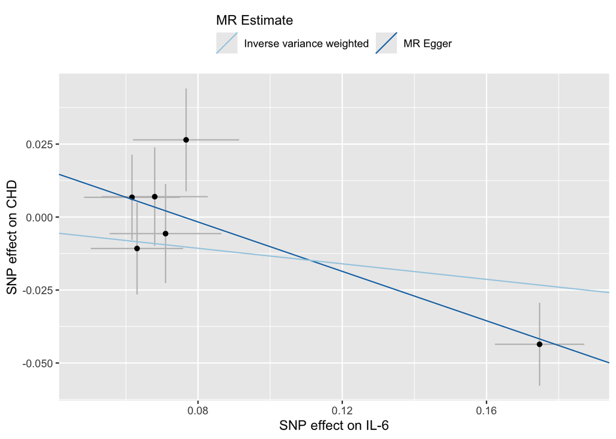

```
##
## attr(,"split_type")
## [1] "data.frame"
## attr(,"split_labels")
##   id.exposure id.outcome
## 1      dRBD6a     IRg4hn
```

```r
p1_il6 <- mr_scatter_plot(res_il6, harm_clump_il6)
p1_il6
```

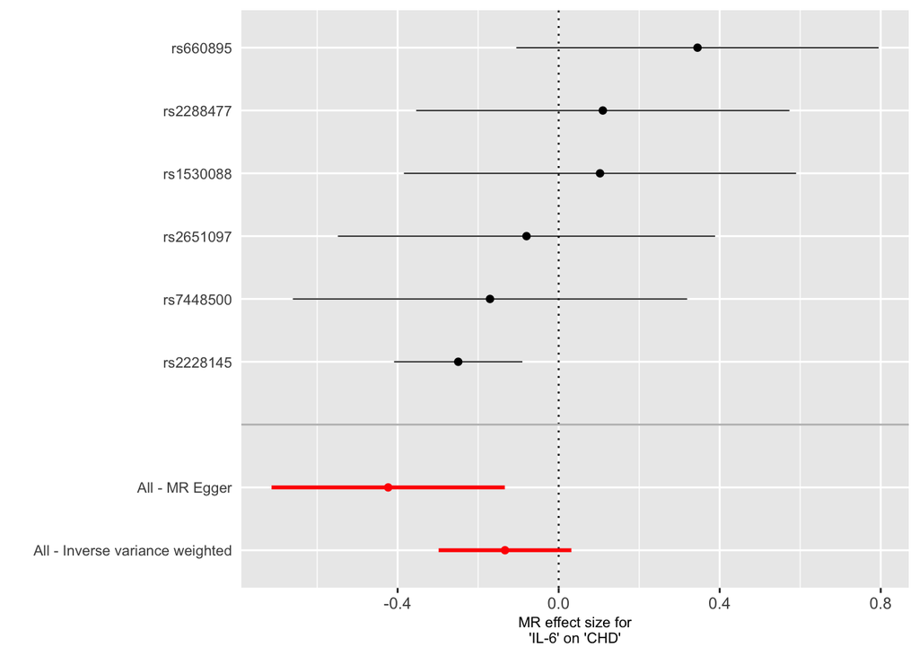

```
##
## attr(,"split_type")
## [1] "data.frame"
## attr(,"split_labels")
##   id.exposure id.outcome
## 1      dRBD6a     IRg4hn
```

```r
res_single_il6 <- mr_singlesnp(harm_clump_il6)
p2_il6 <- mr_forest_plot(res_single_il6)
p2_il6
```

```r
#mr_report(harm_clump_il6, output_path = "figure/")
```

**Exercise:** - Is IL-6 likely to be causally associated with CHD? - How consistent are the results across MR methods?

# 3. MR Analysis of IL6R on CRP

Let’s test whether IL6R levels influence CRP levels.

```r
exposure <- read_exposure_data(
  filename = "data/gwas_catalogue/IL6R-GCST90088597.tsv.gz",
  sep = "\t",
  snp_col = "variant_id",
  beta_col = "beta",
  se_col = "standard_error",
  effect_allele_col = "effect_allele",
  other_allele_col = "other_allele",
  eaf_col = "effect_allele_frequency",
  pval_col = "p_value"
)
```

```
## No phenotype name specified, defaulting to 'exposure'.
```

```r
exposure$exposure <- "IL6R"
exposure <- exposure %>% filter(pval.exposure < 5*10^-8)

outcome <- read_outcome_data(
  snps = exposure$SNP,
  filename = "data/gwas_catalogue/CRP-GCST005067.tsv.gz",
  sep = "\t",
  snp_col = "variant_id",
  beta_col = "beta",
  se_col = "standard_error",
  effect_allele_col = "effect_allele",
  other_allele_col = "other_allele",
  eaf_col = "effect_allele_frequency",
  pval_col = "p_value"
)
```

```
## No phenotype name specified, defaulting to 'outcome'.
```

```r
outcome$outcome <- "CRP"

il6_data <- harmonise_data(exposure_dat = exposure, outcome_dat = outcome)
```

```
## Harmonising IL6R (wiOeB3) and CRP (kPn4um)
```

[output not shown]

```r
clump <- ld_clump(
  dplyr::tibble(rsid=il6_data$SNP, pval=il6_data$pval.exposure,exposure=il6_data$exposure),
  clump_kb = 10000,
  clump_r2 = 0.001,
  clump_p = 0.99,
  pop = "EUR",
  opengwas_jwt = get_opengwas_jwt(),
  bfile = NULL,
  plink_bin = NULL
)
```

```
## Please look at vignettes for options on running this locally if you need to run many instances of this command.
```

```
## Clumping 6VVrsd, 888 variants, using EUR population reference
```

```
## Removing 882 of 888 variants due to LD with other variants or absence from LD reference panel
```

```r
harm_clump_il6_crp <- merge(il6_data, clump, by.x = c("SNP", "pval.exposure", "exposure"), by.y = c("rsid", "pval", "exposure")) %>% unique()

res_il6_crp <- mr(harm_clump_il6_crp, method_list = c("mr_egger_regression", "mr_ivw"))
```

```
## Analysing 'wiOeB3' on 'kPn4um'
```

```r
res_il6_crp
```

```
##   id.exposure id.outcome outcome exposure                    method nsnp
## 1      wiOeB3     kPn4um     CRP     IL6R                  MR Egger    6
## 2      wiOeB3     kPn4um     CRP     IL6R Inverse variance weighted    6
##            b         se         pval
## 1 -0.1164503 0.03743946 0.0358593185
## 2 -0.0831967 0.02475596 0.0007775244
```

```r
mr_heterogeneity(harm_clump_il6_crp)
```

```
##   id.exposure id.outcome outcome exposure                    method        Q
## 1      wiOeB3     kPn4um     CRP     IL6R                  MR Egger 4.485282
## 2      wiOeB3     kPn4um     CRP     IL6R Inverse variance weighted 5.983749
##   Q_df    Q_pval
## 1    4 0.3442962
## 2    5 0.3078034
```

```r
mr_pleiotropy_test(harm_clump_il6_crp)
```

```
##   id.exposure id.outcome outcome exposure egger_intercept         se      pval
## 1      wiOeB3     kPn4um     CRP     IL6R      0.01561581 0.01350846 0.3120247
```

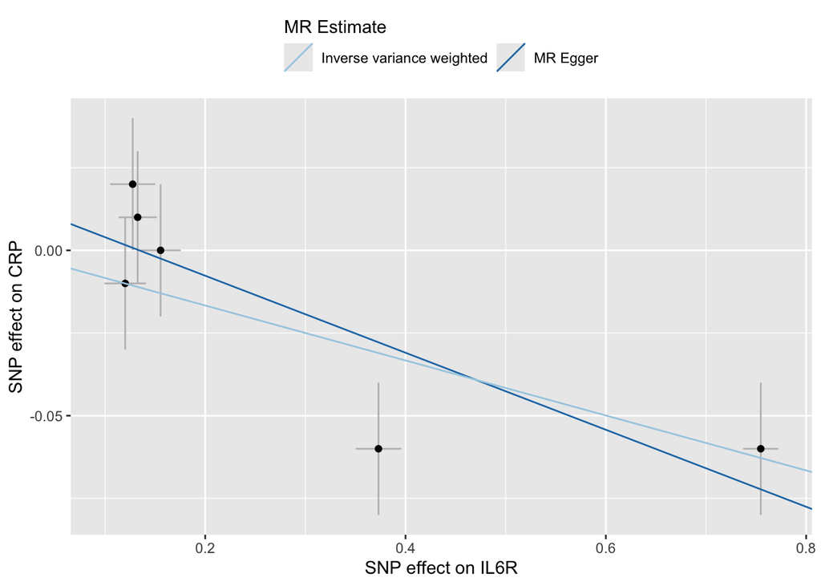

```
##
## attr(,"split_type")
## [1] "data.frame"
## attr(,"split_labels")
##   id.exposure id.outcome
## 1      wiOeB3     kPn4um
```

```r
p1_il6 <- mr_scatter_plot(res_il6_crp, harm_clump_il6_crp)
p1_il6
```

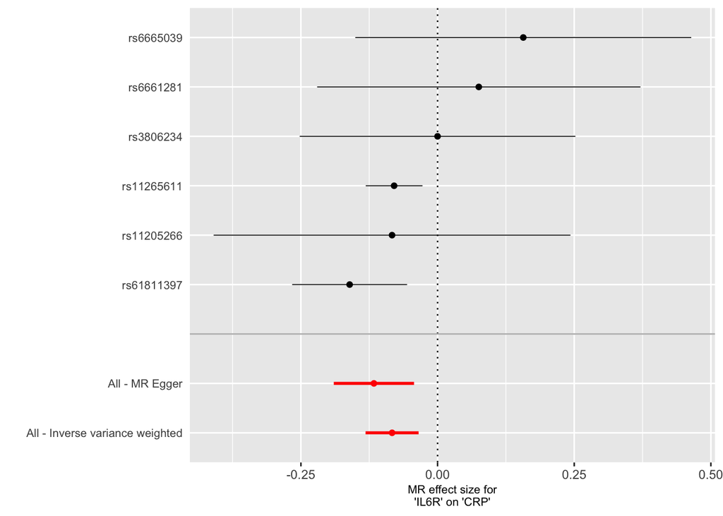

```
##
## attr(,"split_type")
## [1] "data.frame"
## attr(,"split_labels")
##   id.exposure id.outcome
## 1      wiOeB3     kPn4um
```

```r
res_single_il6 <- mr_singlesnp(harm_clump_il6_crp)
p2_il6 <- mr_forest_plot(res_single_il6)
p2_il6
```

**Exercise:** - Is there evidence that IL6R variants causally affect CRP levels? - Does this support IL6R as an upstream regulator of inflammation?

# 4. MR Analysis of IL6R on CHD

Finally, let’s test whether IL6R levels have a causal effect on CHD.

```r
exposure <- read_exposure_data(
  filename = "data/gwas_catalogue/IL6R-GCST90088597.tsv.gz",
  sep = "\t",
  snp_col = "variant_id",
  beta_col = "beta",
  se_col = "standard_error",
  effect_allele_col = "effect_allele",
  other_allele_col = "other_allele",
  eaf_col = "effect_allele_frequency",
  pval_col = "p_value"
)
```

```
## No phenotype name specified, defaulting to 'exposure'.
```

```r
exposure$exposure <- "IL6R"
exposure <- exposure %>% filter(pval.exposure < 5*10^-8)

outcome <- read_outcome_data(
  snps = exposure$SNP,
  filename = "data/gwas_catalogue/CHD_GCST000998.tsv.gz",
  sep = "\t",
  snp_col = "variant_id",
  beta_col = "beta",
  se_col = "standard_error",
  effect_allele_col = "effect_allele",
  other_allele_col = "other_allele",
  eaf_col = "effect_allele_frequency",
  pval_col = "p_value"
)
```

```
## No phenotype name specified, defaulting to 'outcome'.
```

```r
outcome$outcome <- "CHD"

il6R_data <- harmonise_data(exposure_dat = exposure, outcome_dat = outcome)
```

```
## Harmonising IL6R (li5n7E) and CHD (b1cauk)
```

```
## Removing the following SNPs for being palindromic with intermediate allele frequencies:
## rs10908848, rs2987763, rs4601580, rs6699729, rs7531982, rs9330261, rs9426831, rs9427117
```

```r
clump <- ld_clump(
  dplyr::tibble(rsid=il6R_data$SNP, pval=il6R_data$pval.exposure,exposure=il6R_data$exposure),
  clump_kb = 10000,
  clump_r2 = 0.001,
  clump_p = 0.99,
  pop = "EUR",
  opengwas_jwt = get_opengwas_jwt(),
  bfile = NULL,
  plink_bin = NULL
)
```

```
## Please look at vignettes for options on running this locally if you need to run many instances of this command.
```

```
## Clumping JkVc8O, 210 variants, using EUR population reference
```

```
## Removing 205 of 210 variants due to LD with other variants or absence from LD reference panel
```

```r
harm_clump_il6R <- merge(il6R_data, clump, by.x = c("SNP", "pval.exposure", "exposure"), by.y = c("rsid", "pval", "exposure")) %>% unique()

res_il6 <- mr(harm_clump_il6R, method_list = c("mr_egger_regression", "mr_ivw"))
```

```
## Analysing 'li5n7E' on 'b1cauk'
```

```r
res_il6
```

```
##   id.exposure id.outcome outcome exposure                    method nsnp
## 1      li5n7E     b1cauk     CHD     IL6R                  MR Egger    5
## 2      li5n7E     b1cauk     CHD     IL6R Inverse variance weighted    5
##             b         se        pval
## 1 -0.08190643 0.02769831 0.059683306
## 2 -0.05416385 0.01851339 0.003437292
```

```r
mr_heterogeneity(harm_clump_il6R)
```

```
##   id.exposure id.outcome outcome exposure                    method        Q
## 1      li5n7E     b1cauk     CHD     IL6R                  MR Egger 3.388334
## 2      li5n7E     b1cauk     CHD     IL6R Inverse variance weighted 5.232818
##   Q_df    Q_pval
## 1    3 0.3355362
## 2    4 0.2642321
```

```r
mr_pleiotropy_test(harm_clump_il6R)
```

```
##   id.exposure id.outcome outcome exposure egger_intercept         se      pval
## 1      li5n7E     b1cauk     CHD     IL6R      0.01619687 0.01267436 0.2911893
```

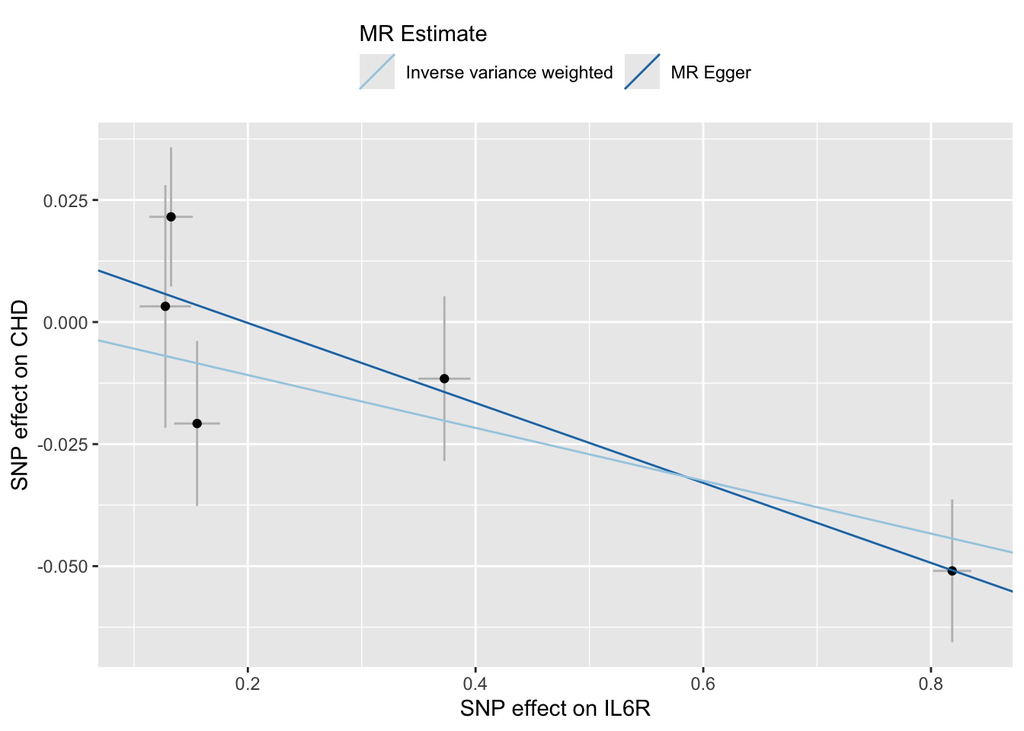

```
##
## attr(,"split_type")
## [1] "data.frame"
## attr(,"split_labels")
##   id.exposure id.outcome
## 1      li5n7E     b1cauk
```

```r
p1_il6 <- mr_scatter_plot(res_il6, harm_clump_il6R)
p1_il6
```

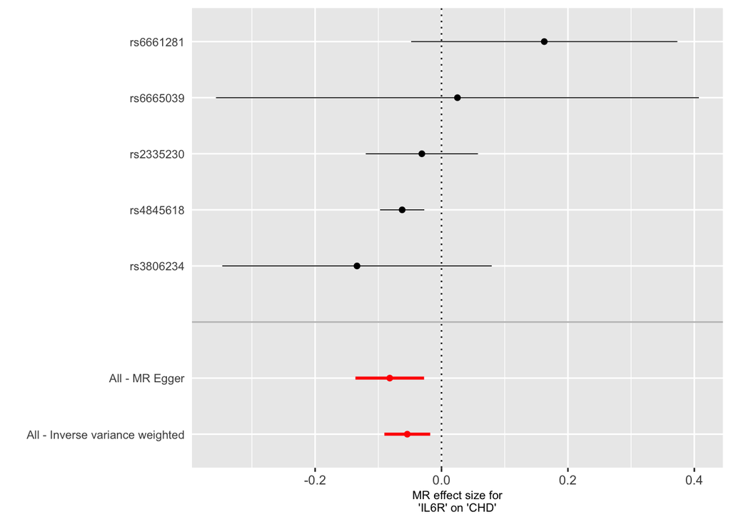

```
##
## attr(,"split_type")
## [1] "data.frame"
## attr(,"split_labels")
##   id.exposure id.outcome
## 1      li5n7E     b1cauk
```

```r
res_single_il6 <- mr_singlesnp(harm_clump_il6R)
p2_il6 <- mr_forest_plot(res_single_il6)
p2_il6
```

**Exercise:** - Do IL6R variants predict CHD risk? - Would this support therapeutic targeting of IL6R (e.g., using tocilizumab)?

These results suggest that **targeting IL6R** may influence CHD risk through inflammatory pathways without CRP being a causal intermediary. This has direct implications for drug repurposing and therapeutic targeting.

# Conclusion

This tutorial demonstrated how to conduct MR using multiple data formats (VCF, TSV, API) and data harmonization pipelines. The CRP–CHD analysis showed no evidence of a causal effect, while IL-6—upstream of CRP—demonstrated a potential causal effect on CHD, supporting the hypothesis that IL-6 may be a better intervention target.